# Capsule 6 - Comparer prudemment

MQT-2101 - Analyse et modélisation des données

## Pourquoi ça compte

Une décision concrète

La compagnie A a 6 incidents, la compagnie B en a 1. A est-elle plus dangereuse?

Impossible à dire sans connaître leur taille. Si A vole dix fois plus que B, son taux peut être plus faible. Comparer sans tenir compte de l’échelle mène à de fausses conclusions.

## Objectifs de la capsule

- Comparer une variable numérique selon une catégorie.
- Distinguer un nombre brut d’un indicateur ajusté à l’échelle.
- Formuler une limite d’interprétation claire.

## Comparer births selon jour_semaine

On compare une variable numérique (`births`) selon une variable catégorielle (`jour_semaine`).

centre

médiane de chaque jour

étendue

dispersion visible

écarts

comparaison entre groupes

## Graphique de comparaison

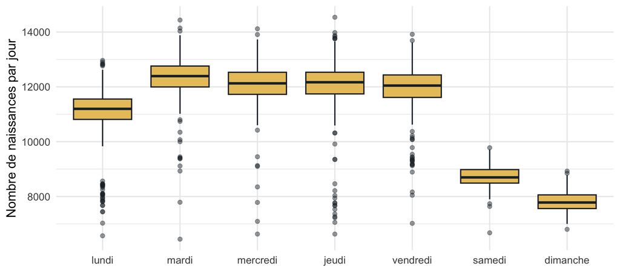

## Le constat, et sa limite

Constat descriptif

Le samedi et le dimanche ont des niveaux nettement plus bas que les jours de semaine.

Limite

Le graphique décrit cet écart ; il n’explique pas pourquoi il existe.

C’est l’écart qui produisait les deux bosses de l’histogramme de la capsule 5.

## Nombre brut et échelle

Dans safety_airlines.csv, les compagnies n’ont ni la même taille ni la même exposition.

| Indicateur | Ce qu’il mesure |
| --- | --- |
| `incidents_00_14` | nombre brut d’incidents |
| `avail_seat_km_per_week` | volume d’activité hebdomadaire |
| `incidents_par_milliard` | incidents par milliard de sièges-km estimés |

## Pourquoi calculer un taux indicatif?

Un taux ramène les incidents à une échelle commune : incidents ÷ exposition. Il rend les compagnies comparables.

L’exposition est **approximée** : on applique un volume hebdomadaire récent sur 15 ans (2000–2014). C’est utile pour l’ordre de grandeur, pas pour une mesure exacte de la sécurité.

## Comparer deux classements

| Compagnie | Incidents 2000-2014 | Taux indicatif |
| --- | --- | --- |
| Pakistan International | 10 | 0.037 |
| Saudi Arabian | 11 | 0.016 |
| Sri Lankan / AirLanka | 4 | 0.016 |
| Ethiopian Airlines | 5 | 0.013 |
| Gulf Air | 3 | 0.013 |
| Royal Air Maroc | 3 | 0.013 |

Si le classement change quand on passe du nombre brut au taux, c’est que l’échelle de comparaison influence l’interprétation.

## La même logique en gestion

Nombre brut

120 plaintes, 8 défauts, 50 000 $ de ventes.

Ramené à une base commune

Plaintes par 1 000 clients, défauts par lot, ventes par employé.

Brut vs taux : même grille de lecture en ventes, en qualité ou en RH.

## Association et causalité

- un boxplot décrit des écarts entre groupes;
- un taux décrit un indicateur sur une échelle commune;
- une cause demande d’autres informations et une analyse adaptée.

Une comparaison descriptive peut révéler une association. Elle ne démontre pas une cause.

## À retenir

1

Comparer demande de nommer les variables et l’échelle.

2

Un nombre brut peut être trompeur sans contexte ; un taux ramène à une base commune.

3

Une comparaison descriptive ne prouve pas une cause.

## Production autonome 1.6

Produisez deux constats descriptifs et une limite.

Comparez `births` selon `jour_semaine`, puis `incidents_00_14` au taux indicatif dans safety_airlines.csv. Terminez par une limite d’interprétation.

### Auto-vérification

- J’ai nommé l’unité d’observation et le type des variables.
- Mon graphique ou mon résumé répond exactement à la question.
- Ma conclusion contient une limite descriptive.